# CSP571 Summer 2022 Project. Gap Phenomenon in Stock Market: Evaluating the Significance of Price Gaps in Predicting Future Returns Using Statistical and Machine Learning Techniques

Oleksandr Shashkov and Santosh Chaluvaraju Illinois Institute of Technology

# Libraries

```r
library(tibble)
library(collections)
library(tidyverse)
library(tidyquant)
library(lubridate)
library(dplyr)
library(timetk)
library(quantmod)
library(corrplot)
library(zoom)
library(caret)
library(Metrics)
library(glmnet)
```

# 1. Removing Survival Bias

```r
# load the S&P500 historical composition
SnP_components_raw <- read.csv(file=file.choose())
```

```r
# form a set of all stocks tickers
tickers_set <- c()
for (composition in SnP_components_raw$tickers) {
  curr_composition <- strsplit(composition,split = ",")
  tickers_set <- unique(c(tickers_set,curr_composition[[1]]))
}
```

```r
# form a dictionary where a key is a ticker
# and a value is a list of data ranges when a stock was in the S&P index
sp500_composition <- dict()
counter = 1
# iterate through the list of historical S&P components
for (tcr in tickers_set) {
  cat("Processing ticker:",tcr,"(",counter,")","\n")
  listed <- FALSE
  # declare time stamp variables
  start_timestamp <- Sys.Date()
  last_timestamp <- Sys.Date()
  # list of ranges when the current stock was a part of S&P index
  range_list <- list()
  # iterate through the time steps
  for (i in 1:nrow(SnP_components_raw)) {
    timestep <- SnP_components_raw[i,]
    curr_timestamp <- timestep$date[[1]][1]
    if (!(tcr %in% strsplit(timestep$tickers,split = ",")[[1]])){
      # ticker is not in the current composition
      if (listed){# stock was listed before but now it is not
        # form an entry in the list containing start and stop time stamps
        range_entry <- list(start_timestamp,last_timestamp)
        # add it to the list of ranges
        range_list <- append(range_list, list(range_entry))

        listed = FALSE
      }
    } else {# ticker is in the current composition
      if (!listed){# stock was not listed previously
        # start tracking new range
        start_timestamp <- curr_timestamp
        listed = TRUE
      }
    }
    last_timestamp <- curr_timestamp
  }
  # we are done with current ticker
  if (listed){  # need to check if the range needs to be closed
    # form an entry in the list containing start and stop time stamps
    range_entry <- list(start_timestamp,last_timestamp)
    # add it to the list of ranges
    range_list <- append(range_list, list(range_entry))
  }
  # add ticker and ranges to global dictionary
  sp500_composition$set(tcr,c(range_list))
  counter <- counter + 1
}
```

# 2. Downloading Data

## 2.1 Downloading Stocks Data

```r
# process dictionary to download stocks data for the ranges
for (stock in sp500_composition$keys()) {
  for (rng in sp500_composition$get(stock)){
    cat("ticker:",stock,"start:",
        format.Date(rng[[1]][1]),
        "stop:",format.Date(rng[[2]][1]),"\n")
    # download stocks data here having ticker and time stamps. tq_get returns data in tibble form, convert tibble data into dataframe before saving
    stock_prices_df <- as.data.frame(tq_get(stock, from = rng[[1]][1], to = rng[[2]][1]))
    # save it to the file
    file_name <- paste(stock,rng[[1]][1],"-",rng[[2]][1], sep = "-")
    #Putting all the files inside data folder
    file_name <- paste("data",file_name,sep = "/")
    file_name <- paste(file_name,"csv", sep = ".")
    write.csv(stock_prices_df , file_name, row.names = FALSE)
  }
}
```

## 2.2 Downloading S&P500 index data

```r
# get S&P500 data for the entire data range:
GSPC <- getSymbols("^GSPC", auto.assign=FALSE, from="1996-01-01", src="yahoo")
GSPC_data <- data.frame(symbol='GSPC',date=time(GSPC),as.matrix(GSPC))
colnames(GSPC_data ) <- c("symbol","date","open","high","low","close","volume","adjusted")
write.csv(GSPC_data,"C:\\Users\\Alex\\Documents\\IIT\\CSP571\\Assignments\\Project\\Gap-Phenomenon-in-Stock-Market\\data\\GSPC.csv", row.names = FALSE)
```

# 3. Data Processing

## 3.1 Loading Saved Data

```r
path <- "/home/santosh/Desktop/MASTERS/STUDIES_MSDS/SEM_2_summer/Data_preparation_and_analysis/PROJECT/git_work/Gap-Phenomenon-in-Stock-Market/data"
filesList <- list.files(path=path, pattern=NULL, all.files=FALSE, full.names=TRUE)

for (file in filesList) {
  #Remove files if it contains less than or equal to 2 columns
  if(ncol(read.csv(file)) <= 2){
    file.remove(file)
  }

}
```

Get all CSV files along with their full path

```r
#path <- "/home/santosh/Desktop/MASTERS/STUDIES_MSDS/SEM_2_summer/Data_preparation_and_analysis/PROJECT/git_work/Gap-Phenomenon-in-Stock-Market/data"
path <- "C:\\Users\\Alex\\Documents\\IIT\\CSP571\\Assignments\\Project\\Gap-Phenomenon-in-Stock-Market\\data"
filesList <- list.files(path=path, pattern=NULL, all.files=FALSE, full.names=TRUE)
```

## 3.2 Gap Detection

```r
detect_gaps <- function(last_h, last_l, h, l)
{
  gap_size = 0.0
  gap_type = "NONE"
  if(last_l > h){
    gap_type = "DOWN"
    gap_size = (h - last_l)/last_l
  }
  else if(last_h < l){
    gap_type = "UP"
    #gap_size = (l - last_h)/last_h
    gap_size = as.numeric((l - last_h)/last_h)
  }
  gap_list = list(gap_type, gap_size)

  return (gap_list)
}
```

## 3.3 Preprocessing S&P 500 index data

```r
# loading data and calculating overnight returns for S&P500 index
spxdf <- read.csv("data/GSPC.csv")
rownames(spxdf) <- spxdf$date
for(i in 1:nrow(spxdf)){
      if(i == 1){
        # fake overnight return with intraday for first entry
        spxdf$return[i] <- (spxdf$close[i]-spxdf$open[i])/spxdf$open[i]
      }
      else{
        spxdf$return[i] <- (spxdf$adjusted[i]-spxdf$adjusted[i-1])/spxdf$adjusted[i-1]
      }
}

#Putting pre processed file inside pre_processed_data folder
file_name <- paste("GSPC", "preprocessed", sep = "_" )
file_name <- paste("pre_processed_data",file_name,sep = "/")
file_name <- paste(file_name,"csv", sep = ".")
spxdf <- apply(spxdf,2,as.character)
write.csv(spxdf , file_name, row.names = FALSE)

# reload spxdf
spxdf <- read.csv("pre_processed_data/GSPC_preprocessed.csv")
rownames(spxdf) <- spxdf$date
```

## 3.4 Preprocessing Stocks Data

Detecting gaps and types, Calculating ranges, relative volume, daily returns and adjusted daily returns and adding it into new columns

```r
for (file in filesList) {
  # load CSV file
  df <- read.csv(file)
  print(file)

  df <- df[!is.na(df$high),]
  df <- df[!is.na(df$low),]
  # Perform preprocessing only if the data frame has more than 25 rows else ignore
  if(nrow(df) > 25){

    gap_list <- list()

    for(i in 1:nrow(df)){
      if(i == 1){
        gap_list[[i]] <- list("NONE", 0.0)
        df$vol_change[i] <- 0.0
        # fake overnight return with intraday for first entry
        df$return[i] <- (df$close[i]-df$open[i])/df$open[i]
      }
      else{
        gap_list[[i]] <- detect_gaps(df$high[i-1], df$low[i-1], df$high[i], df$low[i])
        # calculating relative volume
        df$vol_change[i] <- (df$volume[i] - df$volume[i-1])/df$volume[i-1]
        # calculating daily returns
        # We need overnight return, not intraday
        # And we need to use adjusted close for that
        df$return[i] <- (df$adjusted[i]-df$adjusted[i-1])/df$adjusted[i-1]
      }

      #calculating adjusted returns
      df$adjusted_return[i] <- df$return[i] - spxdf$return[which(rownames(spxdf)==df$date[i])]

    }
    df_temp <- as.data.frame(do.call(rbind, gap_list))
    colnames(df_temp) <- c("gap_type", "gap_size")
    df <- cbind(df, df_temp)
    #adding range column
    df$range <- (df$high - df$low)/df$low

    # extract day of the week and month as potential features
    df$weekday <- wday(df$date, week_start=1)
    df$month <- month(df$date)

    # calculate "candle body metric"
    df$candle_body_metric <- (df$close - df$open)/df$open

    # adding lags and leads
    selected_cols <- c(
      "vol_change","return","adjusted_return","range","weekday","month","candle_body_metric")
    lags_leads <- (-10:10)[as.logical( -10:10 != 0)]# -10...-1 1...10 - omit 0
    df <- df %>% tk_augment_lags(contains(selected_cols), .lags = lags_leads)

    # cleaning up rows with NAs
    df <- na.omit(df)

    #Putting all the pre processed files inside pre_processed_data folder
    file_name <- paste(sub('\\.csv$', '', basename(file)), "preprocessed", sep = "_" )
    file_name <- paste("pre_processed_data",file_name,sep = "/")
    file_name <- paste(file_name,"csv", sep = ".")
    df <- apply(df,2,as.character)
    write.csv(df , file_name, row.names = FALSE)
  }
}
```

```r
# Save all the gaps into a single data frame, preserve it into CSV
#path <- "/home/santosh/Desktop/MASTERS/STUDIES_MSDS/SEM_2_summer/Data_preparation_and_analysis/PROJECT/git_work/Gap-Phenomenon-in-Stock-Market/pre_processed_data"
path <- "C:\\Users\\Alex\\Documents\\IIT\\CSP571\\Assignments\\Project\\Gap-Phenomenon-in-Stock-Market\\pre_processed_data"
filesList <- list.files(path=path, pattern=NULL, all.files=FALSE, full.names=TRUE)
# remove file describing index
filesList <- filesList[!grepl("GSPC",filesList)]
final_stock_df <- data.frame()
for (file in filesList) {
  print(file)
  df <- read.csv(file)
  df <- df[df$gap_type !='NONE',]
  final_stock_df <- rbind(final_stock_df, df)
}

print(nrow(final_stock_df))

#Putting all the pre processed files inside pre_processed_data folder
file_name <- paste("final", "preprocessed", sep = "_" )
file_name <- paste("final_pre_processed_data",file_name,sep = "/")
file_name <- paste(file_name,"csv", sep = ".")
write.csv(final_stock_df , file_name, row.names = FALSE)
```

```r
#cleanup
rm(list=ls())
```

## 3.5 Final Data Clenup

```r
file <- file.choose()
gaps_df <- read.csv(file)
```

```r
dim(gaps_df)
summary(gaps_df)
```

The data has to be cleaned as there are: 1) inf values in vol_change column and lags 2) Enormously high returns in some rows and lags 3) Enormously high ranges in some rows and lags 4) Enormously high gaps in some rows and lags 5) gap_type must be a factor 6) weekday and month and their lags must be factors

```r
summary(gaps_df$vol_change)
quantile(gaps_df$vol_change,probs=c(.01,.99))
hist(gaps_df$vol_change, breaks=1000, main = "Volume change distirbution before the cleanup")
hist(log(gaps_df$vol_change), breaks=1000, main = "Log Volume change distirbution before the cleanup")
```

```r
# removing rows with infinite and unrealistic values of vol_change and its lags
# let's limit it within at least 98% range:  ( -0.642356 < and < 8.261169 )
mx = 8.27
mn = -0.64
gaps_df <- gaps_df[gaps_df$vol_change < mx &  gaps_df$vol_change > mn,]
gaps_df <- gaps_df[gaps_df$vol_change_lag.10 < mx &  gaps_df$vol_change_lag.10 > mn,]
gaps_df <- gaps_df[gaps_df$vol_change_lag.9 < mx &  gaps_df$vol_change_lag.9 > mn,]
gaps_df <- gaps_df[gaps_df$vol_change_lag.8 < mx &  gaps_df$vol_change_lag.8 > mn,]
gaps_df <- gaps_df[gaps_df$vol_change_lag.7 < mx &  gaps_df$vol_change_lag.7 > mn,]
gaps_df <- gaps_df[gaps_df$vol_change_lag.6 < mx &  gaps_df$vol_change_lag.6 > mn,]
gaps_df <- gaps_df[gaps_df$vol_change_lag.5 < mx &  gaps_df$vol_change_lag.5 > mn,]
gaps_df <- gaps_df[gaps_df$vol_change_lag.4 < mx &  gaps_df$vol_change_lag.4 > mn,]
gaps_df <- gaps_df[gaps_df$vol_change_lag.3 < mx &  gaps_df$vol_change_lag.3 > mn,]
gaps_df <- gaps_df[gaps_df$vol_change_lag.2 < mx &  gaps_df$vol_change_lag.2 > mn,]
gaps_df <- gaps_df[gaps_df$vol_change_lag.1 < mx &  gaps_df$vol_change_lag.1 > mn,]
gaps_df <- gaps_df[gaps_df$vol_change_lag10 < mx &  gaps_df$vol_change_lag10 > mn,]
gaps_df <- gaps_df[gaps_df$vol_change_lag9 < mx &  gaps_df$vol_change_lag9 > mn,]
gaps_df <- gaps_df[gaps_df$vol_change_lag8 < mx &  gaps_df$vol_change_lag8 > mn,]
gaps_df <- gaps_df[gaps_df$vol_change_lag7 < mx &  gaps_df$vol_change_lag7 > mn,]
gaps_df <- gaps_df[gaps_df$vol_change_lag6 < mx &  gaps_df$vol_change_lag6 > mn,]
gaps_df <- gaps_df[gaps_df$vol_change_lag5 < mx &  gaps_df$vol_change_lag5 > mn,]
gaps_df <- gaps_df[gaps_df$vol_change_lag4 < mx &  gaps_df$vol_change_lag4 > mn,]
gaps_df <- gaps_df[gaps_df$vol_change_lag3 < mx &  gaps_df$vol_change_lag3 > mn,]
gaps_df <- gaps_df[gaps_df$vol_change_lag2 < mx &  gaps_df$vol_change_lag2 > mn,]
gaps_df <- gaps_df[gaps_df$vol_change_lag1 < mx &  gaps_df$vol_change_lag1 > mn,]
```

```r
summary(gaps_df$vol_change)
hist(gaps_df$vol_change, breaks=100, main = "Volume change distribution after the cleanup")
```

```r
gaps_df$gap_type <- as.factor(gaps_df$gap_type)
gaps_df$weekday <- as.factor(gaps_df$weekday)
gaps_df$month <- as.factor(gaps_df$month)

gaps_df$weekday_lag.10 <- as.factor(gaps_df$weekday_lag.10)
gaps_df$month_lag.10 <- as.factor(gaps_df$month_lag.10)
gaps_df$weekday_lag.9 <- as.factor(gaps_df$weekday_lag.9)
gaps_df$month_lag.9 <- as.factor(gaps_df$month_lag.9)
gaps_df$weekday_lag.8 <- as.factor(gaps_df$weekday_lag.8)
gaps_df$month_lag.8 <- as.factor(gaps_df$month_lag.8)
gaps_df$weekday_lag.7 <- as.factor(gaps_df$weekday_lag.7)
gaps_df$month_lag.7 <- as.factor(gaps_df$month_lag.7)
gaps_df$weekday_lag.6 <- as.factor(gaps_df$weekday_lag.6)
gaps_df$month_lag.6 <- as.factor(gaps_df$month_lag.6)
gaps_df$weekday_lag.5 <- as.factor(gaps_df$weekday_lag.5)
gaps_df$month_lag.5 <- as.factor(gaps_df$month_lag.5)
gaps_df$weekday_lag.4 <- as.factor(gaps_df$weekday_lag.4)
gaps_df$month_lag.4 <- as.factor(gaps_df$month_lag.4)
gaps_df$weekday_lag.3 <- as.factor(gaps_df$weekday_lag.3)
gaps_df$month_lag.3 <- as.factor(gaps_df$month_lag.3)
gaps_df$weekday_lag.2 <- as.factor(gaps_df$weekday_lag.2)
gaps_df$month_lag.2 <- as.factor(gaps_df$month_lag.2)
gaps_df$weekday_lag.1 <- as.factor(gaps_df$weekday_lag.1)
gaps_df$month_lag.1 <- as.factor(gaps_df$month_lag.1)

gaps_df$weekday_lag10 <- as.factor(gaps_df$weekday_lag10)
gaps_df$month_lag10 <- as.factor(gaps_df$month_lag10)
gaps_df$weekday_lag9 <- as.factor(gaps_df$weekday_lag9)
gaps_df$month_lag9 <- as.factor(gaps_df$month_lag9)
gaps_df$weekday_lag8 <- as.factor(gaps_df$weekday_lag8)
gaps_df$month_lag8 <- as.factor(gaps_df$month_lag8)
gaps_df$weekday_lag7 <- as.factor(gaps_df$weekday_lag7)
gaps_df$month_lag7 <- as.factor(gaps_df$month_lag7)
gaps_df$weekday_lag6 <- as.factor(gaps_df$weekday_lag6)
gaps_df$month_lag6 <- as.factor(gaps_df$month_lag6)
gaps_df$weekday_lag5 <- as.factor(gaps_df$weekday_lag5)
gaps_df$month_lag5 <- as.factor(gaps_df$month_lag5)
gaps_df$weekday_lag4 <- as.factor(gaps_df$weekday_lag4)
gaps_df$month_lag4 <- as.factor(gaps_df$month_lag4)
gaps_df$weekday_lag3 <- as.factor(gaps_df$weekday_lag3)
gaps_df$month_lag3 <- as.factor(gaps_df$month_lag3)
gaps_df$weekday_lag2 <- as.factor(gaps_df$weekday_lag2)
gaps_df$month_lag2 <- as.factor(gaps_df$month_lag2)
gaps_df$weekday_lag1 <- as.factor(gaps_df$weekday_lag1)
gaps_df$month_lag1 <- as.factor(gaps_df$month_lag1)

summary(gaps_df)
```

```r
# Saving clean data frame
file_name <- paste("clean", "preprocessed", sep = "_" )
file_name <- paste("final_pre_processed_data",file_name,sep = "/")
file_name <- paste(file_name,"csv", sep = ".")
write.csv(gaps_df , file_name, row.names = FALSE)
```

```r
#cleanup
rm(list=ls())
```

# 4. Data Analysis

```r
# load clean dataframe with gaps
file <- file.choose()
gaps_df <- read.csv(file)
gaps_df$gap_type <- as.factor(gaps_df$gap_type)
gaps_df$weekday <- as.factor(gaps_df$weekday)
gaps_df$month <- as.factor(gaps_df$month)

gaps_df$weekday_lag.10 <- as.factor(gaps_df$weekday_lag.10)
gaps_df$month_lag.10 <- as.factor(gaps_df$month_lag.10)
gaps_df$weekday_lag.9 <- as.factor(gaps_df$weekday_lag.9)
gaps_df$month_lag.9 <- as.factor(gaps_df$month_lag.9)
gaps_df$weekday_lag.8 <- as.factor(gaps_df$weekday_lag.8)
gaps_df$month_lag.8 <- as.factor(gaps_df$month_lag.8)
gaps_df$weekday_lag.7 <- as.factor(gaps_df$weekday_lag.7)
gaps_df$month_lag.7 <- as.factor(gaps_df$month_lag.7)
gaps_df$weekday_lag.6 <- as.factor(gaps_df$weekday_lag.6)
gaps_df$month_lag.6 <- as.factor(gaps_df$month_lag.6)
gaps_df$weekday_lag.5 <- as.factor(gaps_df$weekday_lag.5)
gaps_df$month_lag.5 <- as.factor(gaps_df$month_lag.5)
gaps_df$weekday_lag.4 <- as.factor(gaps_df$weekday_lag.4)
gaps_df$month_lag.4 <- as.factor(gaps_df$month_lag.4)
gaps_df$weekday_lag.3 <- as.factor(gaps_df$weekday_lag.3)
gaps_df$month_lag.3 <- as.factor(gaps_df$month_lag.3)
gaps_df$weekday_lag.2 <- as.factor(gaps_df$weekday_lag.2)
gaps_df$month_lag.2 <- as.factor(gaps_df$month_lag.2)
gaps_df$weekday_lag.1 <- as.factor(gaps_df$weekday_lag.1)
gaps_df$month_lag.1 <- as.factor(gaps_df$month_lag.1)

gaps_df$weekday_lag10 <- as.factor(gaps_df$weekday_lag10)
gaps_df$month_lag10 <- as.factor(gaps_df$month_lag10)
gaps_df$weekday_lag9 <- as.factor(gaps_df$weekday_lag9)
gaps_df$month_lag9 <- as.factor(gaps_df$month_lag9)
gaps_df$weekday_lag8 <- as.factor(gaps_df$weekday_lag8)
gaps_df$month_lag8 <- as.factor(gaps_df$month_lag8)
gaps_df$weekday_lag7 <- as.factor(gaps_df$weekday_lag7)
gaps_df$month_lag7 <- as.factor(gaps_df$month_lag7)
gaps_df$weekday_lag6 <- as.factor(gaps_df$weekday_lag6)
gaps_df$month_lag6 <- as.factor(gaps_df$month_lag6)
gaps_df$weekday_lag5 <- as.factor(gaps_df$weekday_lag5)
gaps_df$month_lag5 <- as.factor(gaps_df$month_lag5)
gaps_df$weekday_lag4 <- as.factor(gaps_df$weekday_lag4)
gaps_df$month_lag4 <- as.factor(gaps_df$month_lag4)
gaps_df$weekday_lag3 <- as.factor(gaps_df$weekday_lag3)
gaps_df$month_lag3 <- as.factor(gaps_df$month_lag3)
gaps_df$weekday_lag2 <- as.factor(gaps_df$weekday_lag2)
gaps_df$month_lag2 <- as.factor(gaps_df$month_lag2)
gaps_df$weekday_lag1 <- as.factor(gaps_df$weekday_lag1)
gaps_df$month_lag1 <- as.factor(gaps_df$month_lag1)
rm(file)
```

## 4.1 Gaps Statistics

```r
total_gaps <- nrow(gaps_df)
cat("Total number of gaps detected:", total_gaps, "\n")
```

```
Total number of gaps detected: 117207
```

```r
gap_types <- summary(gaps_df$gap_type)
up_gaps <-unname(gap_types['UP'])
down_gaps <- unname(gap_types['DOWN'])
cat("Gaps UP:", up_gaps,round(100*up_gaps/total_gaps,digits = 2),"%","\n")
```

```
Gaps UP: 64130 54.72 %
```

```r
cat("Gaps DOWN:", down_gaps,round(100*down_gaps/total_gaps,digits = 2),"%","\n")
```

```
Gaps DOWN: 53077 45.28 %
```

```r
# gaps per weekday
cat("Gaps per weekday:\n")
```

```
Gaps per weekday:
```

```r
round(prop.table(table(gaps_df$weekday)) * 100, digits = 2)
```

```
    1     2     3     4     5
21.45 21.04 18.06 20.03 19.43
```

```r
cat("Gaps UP per weekday:\n")
```

```
Gaps UP per weekday:
```

```r
round(prop.table(table(gaps_df$weekday[gaps_df$gap_type =='UP'])) * 100, digits = 2)
```

```
    1     2     3     4     5
22.00 21.03 18.31 19.04 19.62
```

```r
cat("Gaps DOWN per weekday:\n")
```

```
Gaps DOWN per weekday:
```

```r
round(prop.table(table(gaps_df$weekday[gaps_df$gap_type =='DOWN'])) * 100, digits = 2)
```

```
    1     2     3     4     5
20.78 21.05 17.74 21.23 19.20
```

```r
xl <- "Day of the week"
yl <- "Percentage"
par(mfrow=c(2,2))
barplot(prop.table(table(gaps_df$weekday)) * 100, main = "Gaps per weekday", xlab = xl, ylab = yl)
barplot(prop.table(table(gaps_df$weekday[gaps_df$gap_type =='UP'])) * 100, main = "Gaps UP per weekday", xlab = xl, ylab = yl)
```

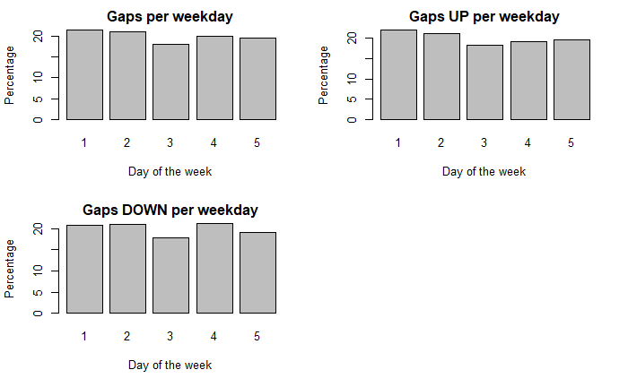

```r
barplot(prop.table(table(gaps_df$weekday[gaps_df$gap_type =='DOWN'])) * 100, main = "Gaps DOWN per weekday", xlab = xl, ylab = yl)
```

```r
# gaps per month
cat("Gaps per month:\n")
```

```
Gaps per month:
```

```r
round(prop.table(table(gaps_df$month)) * 100, digits = 2)
```

```
   1    2    3    4    5    6    7    8    9   10   11   12
7.35 7.99 8.11 9.25 8.73 8.74 8.10 9.10 9.84 9.91 7.99 4.89
```

```r
cat("Gaps UP per month:\n")
```

```
Gaps UP per month:
```

```r
round(prop.table(table(gaps_df$month[gaps_df$gap_type =='UP'])) * 100, digits = 2)
```

```
    1     2     3     4     5     6     7     8     9    10    11    12
 6.98  7.88  7.60 10.41  7.89  8.21  8.72  8.16  9.04 10.89  8.88  5.33
```

```r
cat("Gaps DOWN per month:\n")
```

```
Gaps DOWN per month:
```

```r
round(prop.table(table(gaps_df$month[gaps_df$gap_type =='DOWN'])) * 100, digits = 2)
```

```
    1     2     3     4     5     6     7     8     9    10    11    12
 7.81  8.13  8.72  7.83  9.74  9.38  7.35 10.25 10.80  8.72  6.91  4.36
```

```r
xl <- "Month of the year"
yl <- "Percentage"
par(mfrow=c(2,2))
barplot(prop.table(table(gaps_df$month)) * 100, main = "Gaps per month", xlab = xl, ylab = yl)
barplot(prop.table(table(gaps_df$month[gaps_df$gap_type =='UP'])) * 100, main = "Gaps UP per month", xlab = xl, ylab = yl)
```

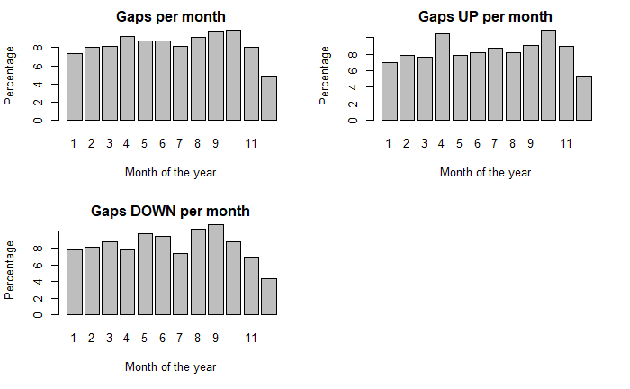

```r
barplot(prop.table(table(gaps_df$month[gaps_df$gap_type =='DOWN'])) * 100, main = "Gaps DOWN per month", xlab = xl, ylab = yl)
```

```r
# Gap sizes
qu <- quantile(gaps_df$gap_size[gaps_df$gap_size > 0],probs=c(.05,.95))
ql <- quantile(gaps_df$gap_size[gaps_df$gap_size < 0],probs=c(.05,.95))
xl <- "Gap size, %"
yl <- "Frequency"
par(mfrow=c(2,2))
hist(100*gaps_df$gap_size[gaps_df$gap_size > 0], breaks=10000, main = "Gap UP size distribution, all", xlab = xl, ylab = yl, col = "green")
hist(-100*gaps_df$gap_size[gaps_df$gap_size < 0], breaks=10000, main = "Gap DOWN size distribution, all", xlab = xl, ylab = yl, col = "red")
```

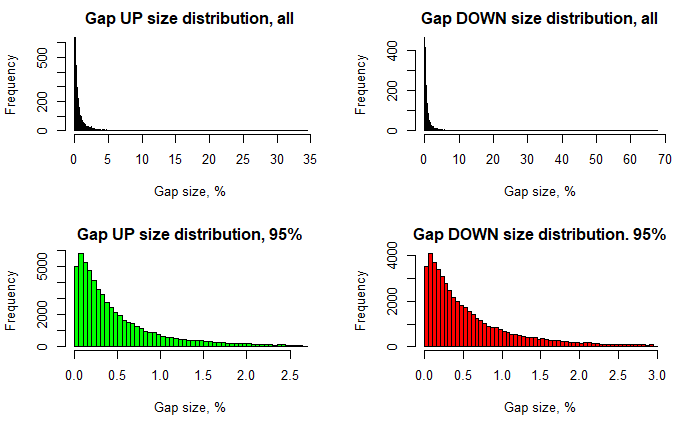

```r
hist(100*gaps_df$gap_size[gaps_df$gap_size > 0 & gaps_df$gap_size < unname(qu["95%"])], breaks=50, main = "Gap UP size distribution, 95%", xlab = xl, ylab = yl, col = "green")
hist(-100*gaps_df$gap_size[gaps_df$gap_size < 0 & gaps_df$gap_size > unname(ql["5%"])], breaks=50, main = "Gap DOWN size distribution. 95%", xlab = xl, ylab = yl, col = "red")
```

```r
qu
```

```
          5%          95%
0.0003497954 0.0265054580
```

```r
ql
```

```
          5%          95%
-0.029657488 -0.000398943
```

```r
# Gap candle range
q <- quantile(gaps_df$range,probs=c(.01,.99))
qu <- quantile(gaps_df$range[gaps_df$gap_type == "UP"],probs=c(.01,.99))
qd <- quantile(gaps_df$range[gaps_df$gap_type == "DOWN"],probs=c(.01,.99))
xl <- "Range, %"
yl <- "Frequency"
par(mfrow=c(3,2))
hist(100*gaps_df$range, breaks=10000, main = "Gap candle range distribution, all", xlab = xl, ylab = yl)
hist(100*gaps_df$range[gaps_df$range < unname(q["99%"])], breaks=50, main = "Gap candle range distribution, 99%", xlab = xl, ylab = yl)
```

```r
hist(100*gaps_df$range[gaps_df$gap_type == "UP"], breaks=10000, main = "Gap UP candle range distribution, all", xlab = xl, ylab = yl)
hist(100*gaps_df$range[gaps_df$gap_type == "UP" & gaps_df$range < unname(qu["99%"])], breaks=50, main = "Gap UP candle range distribution, 99%", xlab = xl, ylab = yl, col = "green")
```

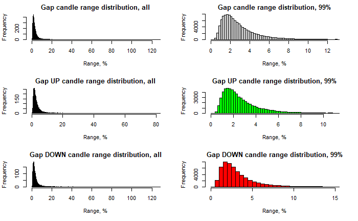

```r
hist(100*gaps_df$range[gaps_df$gap_type == "DOWN"], breaks=10000, main = "Gap DOWN candle range distribution, all", xlab = xl, ylab = yl)
hist(100*gaps_df$range[gaps_df$gap_type == "DOWN" & gaps_df$range < unname(qd["99%"])], breaks=50, main = "Gap DOWN candle range distribution, 99%", xlab = xl, ylab = yl, col = "red")
```

```r
# Gap candle body metric
q <- quantile(gaps_df$candle_body_metric,probs=c(.01,.99))
qu <- quantile(gaps_df$candle_body_metric[gaps_df$gap_type == "UP"],probs=c(.01,.99))
qd <- quantile(gaps_df$candle_body_metric[gaps_df$gap_type == "DOWN"],probs=c(.01,.99))
xl <- "Body Metric, %"
yl <- "Frequency"
par(mfrow=c(3,2))
hist(100*gaps_df$candle_body_metric[gaps_df$candle_body_metric < unname(q["99%"]) & gaps_df$candle_body_metric > unname(q["1%"])], breaks=50, main = "Gap candle body metric distribution", xlab = xl, ylab = yl)
boxplot(100*gaps_df$candle_body_metric, horizontal = TRUE, main = "Gap candle body metric distribution")
```

```r
hist(100*gaps_df$candle_body_metric[gaps_df$gap_type == "UP" & gaps_df$candle_body_metric < unname(qu["99%"]) & gaps_df$candle_body_metric > unname(qu["1%"])], breaks=50, main = "Gap UP candle body metric distribution", xlab = xl, ylab = yl,col = "green")
boxplot(100*gaps_df$candle_body_metric[gaps_df$gap_type == "UP" & gaps_df$candle_body_metric < unname(qu["99%"])& gaps_df$candle_body_metric > unname(qu["1%"])], horizontal = TRUE, main = "Gap UP candle body metric distribution", col = "green")
```

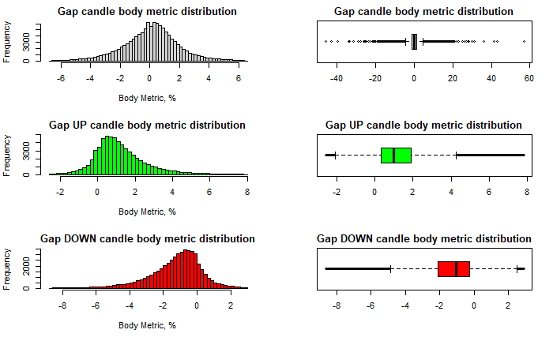

```r
hist(100*gaps_df$candle_body_metric[gaps_df$gap_type == "DOWN" & gaps_df$candle_body_metric < unname(qd["99%"]) & gaps_df$candle_body_metric > unname(qd["1%"])], breaks=50, main = "Gap DOWN candle body metric distribution", xlab = xl, ylab = yl,col = "red")
boxplot(100*gaps_df$candle_body_metric[gaps_df$gap_type == "DOWN" & gaps_df$candle_body_metric < unname(qd["99%"])& gaps_df$candle_body_metric > unname(qd["1%"])], horizontal = TRUE, main = "Gap DOWN candle body metric distribution", col = "red")
```

## 4.2 Correlations

```r
# Consider Correlations for quantitative variables
# Create a sub frame
cleandf <- gaps_df
cols <- colnames(cleandf)
cols
```

```
  [1] "symbol"                    "date"                      "open"                      "high"
  [5] "low"                       "close"                     "volume"                    "adjusted"
  [9] "vol_change"                "return"                    "adjusted_return"           "gap_type"
 [13] "gap_size"                  "range"                     "weekday"                   "month"
 [17] "candle_body_metric"        "vol_change_lag.10"         "return_lag.10"             "adjusted_return_lag.10"
 [21] "range_lag.10"              "weekday_lag.10"            "month_lag.10"              "candle_body_metric_lag.10"
 [25] "vol_change_lag.9"          "return_lag.9"              "adjusted_return_lag.9"     "range_lag.9"
 [29] "weekday_lag.9"             "month_lag.9"               "candle_body_metric_lag.9"  "vol_change_lag.8"
 [33] "return_lag.8"              "adjusted_return_lag.8"     "range_lag.8"               "weekday_lag.8"
 [37] "month_lag.8"               "candle_body_metric_lag.8"  "vol_change_lag.7"          "return_lag.7"
 [41] "adjusted_return_lag.7"     "range_lag.7"               "weekday_lag.7"             "month_lag.7"
 [45] "candle_body_metric_lag.7"  "vol_change_lag.6"          "return_lag.6"              "adjusted_return_lag.6"
 [49] "range_lag.6"               "weekday_lag.6"             "month_lag.6"               "candle_body_metric_lag.6"
 [53] "vol_change_lag.5"          "return_lag.5"              "adjusted_return_lag.5"     "range_lag.5"
 [57] "weekday_lag.5"             "month_lag.5"               "candle_body_metric_lag.5"  "vol_change_lag.4"
```

[output cut: 25 more lines]

```r
cols <- cols[- c(1,2,3,4,5,6,7,8,11,12,15,16,18:81,83:87,90,92,93,97,99,100,104,106,107,111,113,114,118,120,121,125,127,128,132,134,135,139,141,142,146,148,149,153,155,156)]
cols
```

```
 [1] "vol_change"               "return"                   "gap_size"                 "range"                    "candle_body_metric"
 [6] "return_lag.1"             "vol_change_lag1"          "return_lag1"              "range_lag1"               "candle_body_metric_lag1"
[11] "vol_change_lag2"          "return_lag2"              "range_lag2"               "candle_body_metric_lag2"  "vol_change_lag3"
[16] "return_lag3"              "range_lag3"               "candle_body_metric_lag3"  "vol_change_lag4"          "return_lag4"
[21] "range_lag4"               "candle_body_metric_lag4"  "vol_change_lag5"          "return_lag5"              "range_lag5"
[26] "candle_body_metric_lag5"  "vol_change_lag6"          "return_lag6"              "range_lag6"               "candle_body_metric_lag6"
[31] "vol_change_lag7"          "return_lag7"              "range_lag7"               "candle_body_metric_lag7"  "vol_change_lag8"
[36] "return_lag8"              "range_lag8"               "candle_body_metric_lag8"  "vol_change_lag9"          "return_lag9"
[41] "range_lag9"               "candle_body_metric_lag9"  "vol_change_lag10"         "return_lag10"             "range_lag10"
[46] "candle_body_metric_lag10"
```

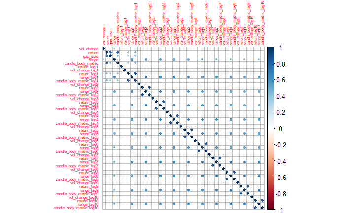

```r
subCleanDf <- cleandf[, cols]
cm <- cor(subCleanDf)
corrplot(cm, tl.cex=0.5)
```

```r
#zm()
```

# 5. Modeling

## 5.1 Linear Model Experiments

```r
# reset the dataframe, include categorical predictors: day and month
cleandf <- gaps_df
cols <- colnames(cleandf)
cols <- cols[- c(1,2,3,4,5,6,7,8,11,18:81,83:87,90,92,93,97,99,100,104,106,107,111,113,114,118,120,121,125,127,128,132,134,135,139,141,142,146,148,149,153,155,156)]
subCleanDf <- cleandf[, cols]
set.seed(1)
train <- createDataPartition(subCleanDf$return_lag.1, p = 0.8, list = FALSE)
stockdf_train <- subCleanDf[train, ]
stockdf_test <- subCleanDf[-train, ]
stockdf_train_model_ln <- lm(return_lag.1 ~., data = stockdf_train)
smry <- summary(stockdf_train_model_ln)
print(smry)
```

```
Call:
lm(formula = return_lag.1 ~ ., data = stockdf_train)

Residuals:
     Min       1Q   Median       3Q      Max
-0.55064 -0.01068  0.00020  0.01080  0.77182

Coefficients:
                           Estimate Std. Error t value Pr(>|t|)
(Intercept)              -4.060e-03  4.122e-04  -9.850  < 2e-16 ***
vol_change               -9.088e-04  1.197e-04  -7.590 3.22e-14 ***
return                   -5.025e-02  6.015e-03  -8.353  < 2e-16 ***
gap_typeUP                3.068e-03  2.671e-04  11.486  < 2e-16 ***
gap_size                  1.081e-01  9.887e-03  10.935  < 2e-16 ***
range                     5.633e-02  4.720e-03  11.933  < 2e-16 ***
weekday2                  1.539e-03  2.562e-04   6.007 1.89e-09 ***
weekday3                 -2.214e-04  2.664e-04  -0.831 0.406040
weekday4                  7.786e-04  2.584e-04   3.013 0.002589 **
weekday5                 -2.286e-03  2.609e-04  -8.761  < 2e-16 ***
month2                    9.353e-05  4.210e-04   0.222 0.824182
month3                    4.395e-03  4.227e-04  10.397  < 2e-16 ***
month4                    3.585e-03  4.104e-04   8.737  < 2e-16 ***
month5                    9.971e-04  4.120e-04   2.420 0.015502 *
month6                    1.678e-03  4.114e-04   4.079 4.52e-05 ***
month7                    2.235e-03  4.178e-04   5.348 8.89e-08 ***
month8                   -2.860e-04  4.093e-04  -0.699 0.484780
month9                    1.284e-03  4.013e-04   3.199 0.001378 **
month10                   1.509e-03  4.008e-04   3.764 0.000168 ***
month11                   3.598e-03  4.216e-04   8.535  < 2e-16 ***
month12                   2.020e-03  4.795e-04   4.213 2.52e-05 ***
candle_body_metric       -1.015e-02  6.846e-03  -1.482 0.138243
vol_change_lag1          -1.110e-03  2.014e-04  -5.510 3.60e-08 ***
return_lag1              -7.148e-02  6.899e-03 -10.360  < 2e-16 ***
range_lag1                8.462e-02  6.752e-03  12.533  < 2e-16 ***
candle_body_metric_lag1  -4.494e-02  8.472e-03  -5.304 1.13e-07 ***
vol_change_lag2          -8.292e-04  2.219e-04  -3.737 0.000186 ***
return_lag2              -3.652e-02  6.419e-03  -5.690 1.27e-08 ***
range_lag2               -1.203e-02  6.173e-03  -1.948 0.051427 .
candle_body_metric_lag2   1.862e-02  7.515e-03   2.477 0.013241 *
vol_change_lag3          -6.062e-04  2.259e-04  -2.683 0.007291 **
```

[output cut: 22 more lines]

```
candle_body_metric_lag8   1.783e-02  7.285e-03   2.447 0.014391 *
vol_change_lag9           5.596e-05  2.084e-04   0.269 0.788248
return_lag9              -1.673e-02  6.138e-03  -2.725 0.006426 **
range_lag9                3.893e-03  5.595e-03   0.696 0.486507
candle_body_metric_lag9   2.700e-02  7.304e-03   3.697 0.000218 ***
vol_change_lag10          4.263e-04  1.864e-04   2.288 0.022156 *
return_lag10              2.719e-02  6.181e-03   4.399 1.09e-05 ***
range_lag10               1.141e-02  5.609e-03   2.034 0.041930 *
candle_body_metric_lag10 -6.419e-02  7.470e-03  -8.594  < 2e-16 ***
---
Signif. codes:  0 ‘***’ 0.001 ‘**’ 0.01 ‘*’ 0.05 ‘.’ 0.1 ‘ ’ 1

Residual standard error: 0.02509 on 93705 degrees of freedom
Multiple R-squared:  0.03781,   Adjusted R-squared:  0.03719
F-statistic: 60.37 on 61 and 93705 DF,  p-value: < 2.2e-16
```

```r
confint(stockdf_train_model_ln)
```

```
                                 2.5 %        97.5 %
(Intercept)              -4.868289e-03 -3.252450e-03
vol_change               -1.143457e-03 -6.741123e-04
return                   -6.203645e-02 -3.845638e-02
gap_typeUP                2.544172e-03  3.591056e-03
gap_size                  8.873128e-02  1.274879e-01
range                     4.707467e-02  6.557779e-02
weekday2                  1.036786e-03  2.040948e-03
weekday3                 -7.435449e-04  3.008156e-04
weekday4                  2.720867e-04  1.285168e-03
weekday5                 -2.797515e-03 -1.774659e-03
month2                   -7.315695e-04  9.186231e-04
month3                    3.566339e-03  5.223333e-03
month4                    2.780972e-03  4.389666e-03
month5                    1.896982e-04  1.804521e-03
month6                    8.719920e-04  2.484790e-03
month7                    1.415694e-03  3.053452e-03
month8                   -1.088283e-03  5.163221e-04
month9                    4.973068e-04  2.070266e-03
month10                   7.229421e-04  2.294182e-03
month11                   2.772034e-03  4.424759e-03
month12                   1.080397e-03  2.959819e-03
candle_body_metric       -2.356540e-02  3.269577e-03
vol_change_lag1          -1.504815e-03 -7.151218e-04
return_lag1              -8.499776e-02 -5.795346e-02
range_lag1                7.138861e-02  9.785511e-02
candle_body_metric_lag1  -6.154506e-02 -2.833371e-02
vol_change_lag2          -1.264164e-03 -3.943023e-04
return_lag2              -4.910212e-02 -2.394154e-02
range_lag2               -2.412488e-02  7.448968e-05
candle_body_metric_lag2   3.887263e-03  3.334479e-02
vol_change_lag3          -1.048934e-03 -1.634007e-04
return_lag3              -8.660417e-02 -6.341759e-02
range_lag3               -1.655494e-02  8.317466e-03
candle_body_metric_lag3   5.201728e-02  8.031806e-02
vol_change_lag4          -1.249188e-03 -3.806614e-04
return_lag4              -9.694418e-02 -7.175691e-02
range_lag4                2.701028e-02  5.200155e-02
candle_body_metric_lag4   4.553007e-02  7.583934e-02
vol_change_lag5          -7.695593e-04  9.314062e-05
```

[output cut: 8 more lines]

```
return_lag7              -6.568634e-02 -4.166419e-02
range_lag7                2.149398e-02  4.600952e-02
candle_body_metric_lag7   8.275030e-03  3.661037e-02
vol_change_lag8          -3.728940e-04  4.735278e-04
return_lag8              -9.818506e-04  2.340305e-02
range_lag8               -5.761087e-02 -3.406818e-02
candle_body_metric_lag8   3.550454e-03  3.210562e-02
vol_change_lag9          -3.524316e-04  4.643605e-04
return_lag9              -2.875862e-02 -4.697287e-03
range_lag9               -7.072717e-03  1.485960e-02
candle_body_metric_lag9   1.268635e-02  4.131652e-02
vol_change_lag10          6.107289e-05  7.915541e-04
return_lag10              1.507410e-02  3.930214e-02
range_lag10               4.164830e-04  2.240315e-02
candle_body_metric_lag10 -7.883313e-02 -4.955188e-02
```

Based on p-values and confidence intervals the following predictors seem to be insignificant in linear regression model:

candle_body_metric candle_body_metric_lag5

range_lag2 range_lag3 range_lag6 range_lag9

vol_change_lag5 vol_change_lag6 vol_change_lag8 vol_change_lag9

return_lag5 return_lag6 return_lag8

```r
predictTrain <- predict(stockdf_train_model_ln, newdata = stockdf_train)
cat("Training MSE" , mse(stockdf_train$return_lag.1, predictTrain), "\n")
```

```
Training MSE 0.0006288816
```

```r
cat("Training RMSE" , rmse(stockdf_train$return_lag.1, predictTrain), "\n")
```

```
Training RMSE 0.02507751
```

```r
cat("Model's R-squared" , smry$r.squared, "\n")
```

```
Model's R-squared 0.03781321
```

Performance metrics on test data linear regression:

```r
predictTest <- predict(stockdf_train_model_ln, newdata = stockdf_test)
cat("Test MSE" , mse(stockdf_test$return_lag.1, predictTest), "\n")
```

```
Test MSE 0.0006037611
```

```r
cat("Test RMSE" , rmse(stockdf_test$return_lag.1, predictTest), "\n")
```

```
Test RMSE 0.02457155
```

Based on R-squared the linear model is not good. That’s is OK as we just wanted to see F-statistics to help with analyzing the significance of the predictors

## 5.2 Lasso Regression Experiments

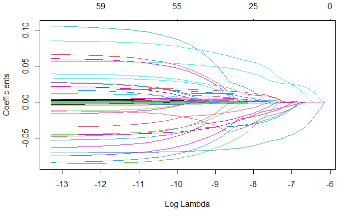

```r
# Let's try Lasso Regression
x_train <- model.matrix(stockdf_train$return_lag.1 ~., data = stockdf_train)[, -9]
y_train <- stockdf_train$return_lag.1
# display how coefficients change with lambda
lasso_model <- glmnet(x_train, y_train, alpha = 1)
plot(lasso_model, "lambda")
```

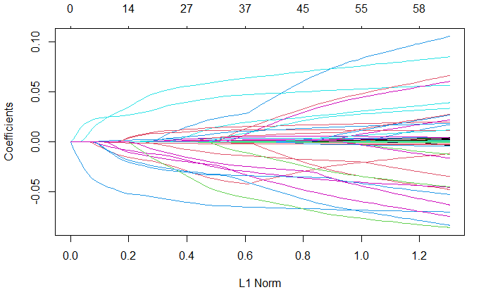

```r
plot(lasso_model, "norm")
```

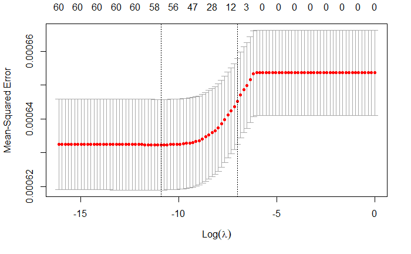

```r
#coef(lasso_model)
grid <- 10^seq(0, -7, length = 100)
lasso_cv_model <- cv.glmnet(x_train, y_train, alpha = 1, lambda = grid)
plot(lasso_cv_model)
```

```r
best_lambda <- lasso_cv_model$lambda.min
cat("Best Lambda: ", best_lambda, "\n")
```

```
Best Lambda:  1.830738e-05
```

```r
summary(lasso_cv_model)
```

```
           Length Class  Mode
lambda     100    -none- numeric
cvm        100    -none- numeric
cvsd       100    -none- numeric
cvup       100    -none- numeric
cvlo       100    -none- numeric
nzero      100    -none- numeric
call         5    -none- call
name         1    -none- character
glmnet.fit  12    elnet  list
lambda.min   1    -none- numeric
lambda.1se   1    -none- numeric
index        2    -none- numeric
```

```r
coef(lasso_cv_model)
```

```
62 x 1 sparse Matrix of class "dgCMatrix"
                                    s1
(Intercept)              -0.0005137145
(Intercept)               .
vol_change                .
return                    .
gap_typeUP                .
gap_size                  .
range                     0.0244754212
weekday2                  .
weekday3                  .
weekday5                 -0.0007108286
month2                    .
month3                    0.0006796256
month4                    .
month5                    .
month6                    .
month7                    .
month8                    .
month9                    .
month10                   .
month11                   .
month12                   .
candle_body_metric       -0.0089849720
vol_change_lag1           .
return_lag1              -0.0450012530
range_lag1                0.0241945077
candle_body_metric_lag1  -0.0050982599
vol_change_lag2           .
return_lag2               .
range_lag2                .
candle_body_metric_lag2   .
vol_change_lag3           .
return_lag3              -0.0001917142
range_lag3                .
candle_body_metric_lag3   .
vol_change_lag4           .
return_lag4              -0.0096067013
range_lag4                .
candle_body_metric_lag4   .
```

[output cut: 9 more lines]

```
return_lag7              -0.0084714276
range_lag7                .
candle_body_metric_lag7   .
vol_change_lag8           .
return_lag8               .
range_lag8                .
candle_body_metric_lag8   .
vol_change_lag9           .
return_lag9               .
range_lag9                .
candle_body_metric_lag9   .
vol_change_lag10          .
return_lag10              .
range_lag10               .
candle_body_metric_lag10  .
```

```r
# get test performance
x_test <- model.matrix(stockdf_test$return_lag.1~. , data = stockdf_test)[, -9]
lasso_pred <- predict(lasso_cv_model, s = best_lambda, newx = x_test)
test_mse <- mse(stockdf_test$return_lag.1, lasso_pred)
cat("Test MSE" , test_mse, "\n")
```

```
Test MSE 0.0006036628
```

Lasso regression rendered the following variables as not significant:

gap_type gap_size

vol_change vol_change_lag1 vol_change_lag2 vol_change_lag3 vol_change_lag4 vol_change_lag5 vol_change_lag6 vol_change_lag7 vol_change_lag8 vol_change_lag9 vol_change_lag10

return return_lag2 return_lag5 return_lag6 return_lag8 return_lag9 return_lag10

range_lag2 range_lag3 range_lag4 range_lag5 range_lag6 range_lag7 range_lag8 range_lag9 range_lag10

candle_body_metric_lag2 candle_body_metric_lag3 candle_body_metric_lag4 candle_body_metric_lag5 candle_body_metric_lag6 candle_body_metric_lag7 candle_body_metric_lag8 candle_body_metric_lag9 candle_body_metric_lag10

```r
#cleanup
rm(list=ls())
```